#### CA03 - *An Introduction to Artificial Intelligence* - Dr. Fadaei **Mohammad Montazeri - 810699269**

# Machine Learning in Data Analysis

## Section One: Exploratory Data Analysis

In this section, we try to approach a better understanding of the given data. In fact, we will examine the raw data. This analysis of data is known as EDA and is used to gain an overview of the dataset's overall structure.

#### 1 - Finding the overall structure of the data

The `info()` and `describe()` methods in pandas are useful for gaining insights into the overall structure and summary statistics of a dataset, respectively. The `info()` method provides a concise summary of the DataFrame, including information about the data types, non-null values, and memory usage. The `describe()` method generates various summary statistics, including measures of central tendency, dispersion, and shape of the distribution. This method is particularly useful for numerical data. Here's an example:

```python
import pandas as pd

# defining 'df' as our DataFrame
df = pd.read_csv('marketing_campaign.csv')

# Drop the first column (row number or index column)
df.drop(df.columns[0], axis=1, inplace=True)

# Display information about the DataFrame
df.info()

# Display summary statistics of the DataFrame
df.describe()
```

```
<class 'pandas.core.frame.DataFrame'>
RangeIndex: 2240 entries, 0 to 2239
Data columns (total 19 columns):
 #   Column             Non-Null Count  Dtype
---  ------             --------------  -----
 0   ID                 2240 non-null   int64
 1   Year_Birth         2240 non-null   int64
 2   Education          2240 non-null   object
 3   Marital_Status     2240 non-null   object
 4   Income             2017 non-null   float64
 5   Kidhome            2240 non-null   int64
 6   Teenhome           2240 non-null   int64
 7   Dt_Customer        2240 non-null   object
 8   Recency            2240 non-null   int64
 9   MntCoffee          2035 non-null   float64
 10  MntFruits          2240 non-null   int64
 11  MntMeatProducts    2240 non-null   int64
 12  MntFishProducts    2240 non-null   int64
 13  MntSweetProducts   2240 non-null   int64
 14  MntGoldProds       2227 non-null   float64
 15  NumWebVisitsMonth  2040 non-null   float64
 16  Complain           2240 non-null   int64
 17  NumPurchases       2240 non-null   int64
 18  UsedCampaignOffer  2240 non-null   int64
dtypes: float64(4), int64(12), object(3)
memory usage: 332.6+ KB
```

|  | ID | Year_Birth | Income | Kidhome | Teenhome | Recency | MntCoffee | MntFruits | MntMeatProducts | MntFishProducts | MntSweetProducts | MntGoldProds | NumWebVisitsMonth | Complain | NumPurchases | UsedCampaignOffer |
| --- | --- | --- | --- | --- | --- | --- | --- | --- | --- | --- | --- | --- | --- | --- | --- | --- |
| count | 2240.000000 | 2240.000000 | 2017.000000 | 2240.000000 | 2240.000000 | 2240.000000 | 2035.000000 | 2240.000000 | 2240.000000 | 2240.000000 | 2240.000000 | 2227.000000 | 2040.000000 | 2240.000000 | 2240.000000 | 2240.000000 |
| mean | 5592.159821 | 1968.805804 | 52297.080317 | 0.437946 | 0.506250 | 49.109375 | 304.239312 | 26.302232 | 166.950000 | 37.525446 | 27.062946 | 43.847777 | 5.326961 | 0.009375 | 14.862054 | 0.271875 |
| std | 3246.662198 | 11.984069 | 25543.108215 | 0.563666 | 0.544538 | 28.962453 | 337.515534 | 39.773434 | 225.715373 | 54.628979 | 41.280498 | 51.897098 | 2.439349 | 0.096391 | 7.677173 | 0.445025 |
| min | 0.000000 | 1893.000000 | 2447.000000 | -5.000000 | 0.000000 | 0.000000 | 0.000000 | 0.000000 | 0.000000 | 0.000000 | 0.000000 | 0.000000 | 0.000000 | 0.000000 | 0.000000 | 0.000000 |
| 25% | 2828.250000 | 1959.000000 | 35340.000000 | 0.000000 | 0.000000 | 24.000000 | 23.000000 | 1.000000 | 16.000000 | 3.000000 | 1.000000 | 9.000000 | 3.000000 | 0.000000 | 8.000000 | 0.000000 |
| 50% | 5458.500000 | 1970.000000 | 51369.000000 | 0.000000 | 0.000000 | 49.000000 | 177.000000 | 8.000000 | 67.000000 | 12.000000 | 8.000000 | 24.000000 | 6.000000 | 0.000000 | 15.000000 | 0.000000 |
| 75% | 8427.750000 | 1977.000000 | 68316.000000 | 1.000000 | 1.000000 | 74.000000 | 505.000000 | 33.000000 | 232.000000 | 50.000000 | 33.000000 | 56.000000 | 7.000000 | 0.000000 | 21.000000 | 1.000000 |
| max | 11191.000000 | 1996.000000 | 666666.000000 | 2.000000 | 2.000000 | 99.000000 | 1493.000000 | 199.000000 | 1725.000000 | 259.000000 | 263.000000 | 362.000000 | 20.000000 | 1.000000 | 44.000000 | 1.000000 |

#### 2 - Finding the number and percentage of missed values for each feature

This can be done using `isnull()` method from *pandas* package. After that, we find the percentage of missing data for each feature by dividing the obtained value by the total number of data.

```python
missing_data_count = df.isnull().sum()
print(missing_data_count)
print()
m_d_c = dict(missing_data_count)

for key, value in m_d_c.items():
    if value:
        print(key,':\t', value/len(df)*100)
```

```
ID                     0
Year_Birth             0
Education              0
Marital_Status         0
Income               223
Kidhome                0
Teenhome               0
Dt_Customer            0
Recency                0
MntCoffee            205
MntFruits              0
MntMeatProducts        0
MntFishProducts        0
MntSweetProducts       0
MntGoldProds          13
NumWebVisitsMonth    200
Complain               0
NumPurchases           0
UsedCampaignOffer      0
dtype: int64

Income :	 9.955357142857142
MntCoffee :	 9.151785714285714
MntGoldProds :	 0.5803571428571429
NumWebVisitsMonth :	 8.928571428571429
```

#### 3 - Plotting the dependence of features to each other and seeing which features our target is most dependent on

Here we plot the dependence of features to each other. Then, we can see which features our target is most dependent on. To do so, we should ignore those columns of our data set which have string values. To store the numerical features only, we create a new data frame called float_df. Then we plot the desired information and finally sort the results. We'll see that the *Amount spent on coffee in last 2 years* at very most, and after that, *Customer's yearly household income* have the most influence on the target which is *Number of purchased products in last 2 years*.

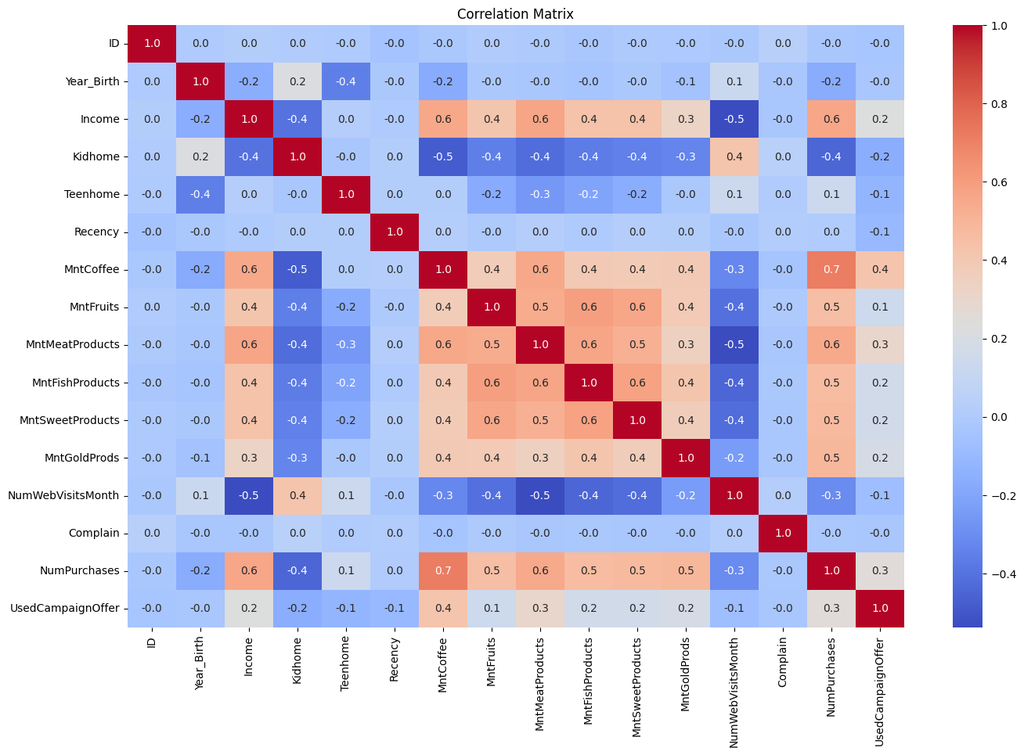

```
Correlation of features with the target column:
NumPurchases         1.000000
MntCoffee            0.715164
Income               0.562603
MntMeatProducts      0.554229
MntGoldProds         0.493939
MntSweetProducts     0.472876
MntFishProducts      0.469454
MntFruits            0.455461
UsedCampaignOffer    0.251386
Teenhome             0.133163
Recency              0.005740
Complain             0.020583
ID                   0.023834
Year_Birth           0.168304
NumWebVisitsMonth    0.309666
Kidhome              0.447073
Name: NumPurchases, dtype: float64
```

```python
import seaborn as sns
import matplotlib.pyplot as plt

# Select only numerical columns
numerical_columns = df.select_dtypes(include=['float64', 'int64'])

# Create a new DataFrame 'float_df' with only numerical columns
float_df = pd.DataFrame(data=numerical_columns)

# Calculate the correlation matrix
correlation_matrix = float_df.corr()

# Measure the correlation of features with the target column
correlation_with_target = abs(correlation_matrix['NumPurchases'].sort_values(ascending=False))

# Plot a heatmap of the correlation matrix
plt.figure(figsize=(16, 10))
sns.heatmap(correlation_matrix, annot=True, cmap='coolwarm', fmt=".1f")
plt.title('Correlation Matrix')
plt.show()

# Display the correlation of features with the target column
print("Correlation of features with the target column:")
print(correlation_with_target)
```

#### 4 - Plotting the number of **unique** values appeared for each feature

As expected, *ID*s are unique for each sample. After that, the *income* seems to have most unique values.

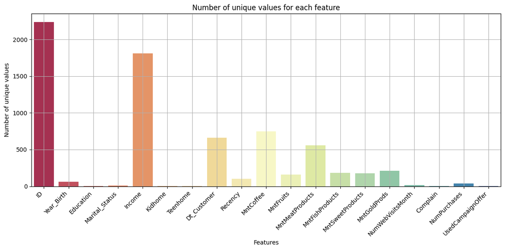

```python
# Finding the count of unique values for each feature
n_unique = df.nunique()

# Plotting the result using a bar chart
plt.figure(figsize=(12, 6))
sns.barplot(x=n_unique.index, y=n_unique.values, palette="Spectral")
plt.ylabel("Number of unique values")
plt.xlabel("Features")
plt.title("Number of unique values for each feature")
plt.xticks(rotation=45, ha="right")
plt.tight_layout()
plt.grid(True)
plt.show()
```

#### 5 - Revising the relation between features and target by plotting a scatter chart

Here, we revise the relation between features and target by plotting the scatter chart of the most important features for our target. Plotting the *Number Of Purchases vs Income/MntCoffee* as two of the most influencing parameters on the *NumPurchases*, results in the following charts:

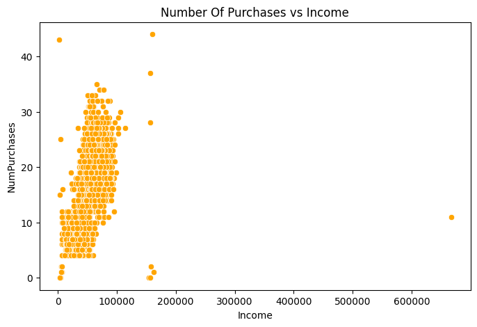

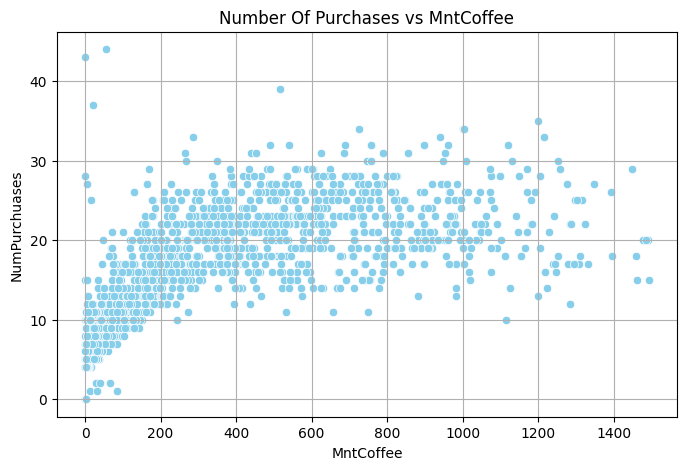

```python
# Plotting the relation between income and NumPurchases
plt.figure(figsize=(8, 5))
sns.scatterplot(x=df['Income'], y=df['NumPurchases'], color='orange')
plt.title("Number Of Purchases vs Income")
plt.xlabel("Income")

# Plotting the relation between MntCoffee and NumPurchases
plt.figure(figsize=(8, 5))
sns.scatterplot(x=df['MntCoffee'], y=df['NumPurchases'], color='skyblue')
plt.title("Number Of Purchases vs MntCoffee")
plt.xlabel("MntCoffee")
plt.ylabel("NumPurchuases")

plt.grid()
plt.show()
```

## Section Two: Preprocessing

In this section we try to enhance the data quality. As a matter of fact, in the real world, collected data is not easily controlled, and as a result, values outside the range or impossible, lost, and generally misleading elements exist in the dataset for training models. Therefore, before continuing with the project, these issues need to be identified and corrected. Additionally, sometimes changing the format of the data and making it more concise can improve the model's performance and learning speed. Ultimately, this phase is the most crucial phase of a machine learning project; otherwise, the output will be very inaccurate, adhering to the principle "garbage in, garbage out."

#### 7 - Exploring different methods to deal with **missing values**

1. **Deletion of Rows or Columns:**
   - **Pros:** Simple and straightforward approach, avoiding imputation of potentially inaccurate values.
   - **Cons:** Leads to loss of information, especially if the column contains crucial data. May reduce dataset size, impacting model performance.
2. **Imputation with Statistics:**
   - **Mean/Median/Mode Imputation:**
     - **Pros:** Preserves overall dataset structure; simple to implement.
     - **Cons:** Ignores potential feature relationships; sensitive to outliers, especially when using the mean.
   - **Imputation with Machine Learning Models:**
     - **Pros:** Considers relationships between features; provides a sophisticated way to fill missing values.
     - **Cons:** Requires additional computational resources; performance depends on the chosen model.
3. **Interpolation:**
   - **Pros:** Suitable for time-series data; preserves trends in the dataset.
   - **Cons:** May not work well for non-linear or irregularly sampled data.
4. **Predictive Modeling:**
   - **Pros:** Utilizes existing information to predict missing values.
   - **Cons:** Complexity depends on the chosen model; overfitting can be an issue.
5. **Multiple Imputation:**
   - **Pros:** Provides a range of plausible values for missing data; accounts for uncertainty in imputation.
   - **Cons:** Requires multiple imputations, which can be computationally intensive.

#### 8 - Deciding what to do with the missing values

According to results of part 2 in previous section, the 4 following parameters have missing values:

- Income
- MntCoffee
- MntGoldProds
- NumWebVisitsMonth

In order to simplify the process, it's decided to use the easiest (but maybe not the best) solution: delete entire rows in which there's missing values.

```python
# Removing rows with Null values
df = df.dropna()
```

#### 9 - What are *normalizing* and *standardizing* and why do we need them?

In numerical features, normalizing or standardizing is performed to bring the values of different features to a similar scale. This process helps prevent certain features from dominating others, especially in machine learning algorithms that are sensitive to the scale of input features. Normalizing typically scales the data to a range of 0 to 1, while standardizing transforms the data to have a mean of 0 and a standard deviation of 1. These techniques make it easier for models to learn patterns from the data and improve the convergence and performance of various algorithms.  
In this project, we'd better use one of these methods because the data of some parameters are noticeably larger than others. This gets more crucial for some algorithms with more sensitivity to the scale, such as K-Nearest-Neighbors (KNN).

#### 10 - Preprocessing techniques for categorical features

For using categorical features, which are typically stored as strings or objects in a dataset, several preprocessing techniques are useful during model training. Some of these techniques include:

1. **Label Encoding:** Convert categorical labels into numerical values. Suitable for ordinal categorical data, where the order matters.
2. **One-Hot Encoding:** Represent each category as a binary vector, creating binary columns for each category. Suitable for nominal categorical data, where there is no inherent order among categories.
3. **Embedding:** Map categorical values to continuous vectors of fixed dimensions. Commonly employed in deep learning models for handling categorical data with large cardinality.
4. **Frequency Encoding:** Encode categorical labels based on their frequency or occurrence in the dataset. Can be useful when the frequency of categories carries relevant information.
5. **Target Encoding (Mean Encoding):** Encode categorical labels based on the mean of the target variable for each category. Effective when there is a correlation between the categorical feature and the target variable.
6. **Handling Missing Values:** Address missing values in categorical features through techniques like imputation or creating a separate category for missing values. Essential for models that cannot handle missing data.

It's not necessary for all categorical data to undergo these preprocessing techniques. The choice depends on the nature of the categorical features, the machine learning algorithm being used, and the specific requirements of the problem. Here we use One-Hot Encoding method to pre-process the categorical features *Education* and *Marital_Status*.

```python
# One-Hot Encoding
df = pd.get_dummies(df, columns=['Education', 'Marital_Status'])

# Extract the target column to move to the last position of DataFrame
column_to_move = df.pop('NumPurchases')
df['NumPurchases'] = column_to_move

# Printing the first 4 rows of the DataFrame to the console
df.head(4)
```

|  | ID | Year_Birth | Income | Kidhome | Teenhome | Dt_Customer | Recency | MntCoffee | MntFruits | MntMeatProducts | ... | Education_PhD | Marital_Status_Absurd | Marital_Status_Alone | Marital_Status_Divorced | Marital_Status_Married | Marital_Status_Single | Marital_Status_Together | Marital_Status_Widow | Marital_Status_YOLO | NumPurchases |
| --- | --- | --- | --- | --- | --- | --- | --- | --- | --- | --- | --- | --- | --- | --- | --- | --- | --- | --- | --- | --- | --- |
| 3 | 6182 | 1984 | 26646.0 | 1 | 0 | 10/2/2014 | 26 | 11.0 | 4 | 20 | ... | False | False | False | False | False | False | True | False | False | 8 |
| 4 | 5324 | 1981 | 58293.0 | 1 | 0 | 19-01-2014 | 94 | 173.0 | 43 | 118 | ... | True | False | False | False | True | False | False | False | False | 19 |
| 6 | 965 | 1971 | 55635.0 | 0 | 1 | 13-11-2012 | 34 | 235.0 | 65 | 164 | ... | False | False | False | True | False | False | False | False | False | 21 |
| 7 | 6177 | 1985 | 33454.0 | 1 | 0 | 8/5/2013 | 32 | 76.0 | 10 | 56 | ... | True | False | False | False | True | False | False | False | False | 10 |

4 rows × 30 columns

#### 11 - Can any column be emitted entirely?

Yes! Some features that can be assumed to be independent of the target feature. E.g.: the *Recency* has a very small (0.005740) correlation with the NumPurchases according to the results of part 3 in previous section; therefore it can be eliminated in training the model without fear of loss of vital info. In addition, the *Dt_Customer* feature seems to be irrelevant to the target feature, so we omit it as well.

```python
# Emitting the Recency feature
df = df.drop('Recency', axis=1)
df = df.drop('Dt_Customer', axis=1)
```

#### 12 - How to split the given data into training and test set?

The ratio of this split depends on the size of the dataset and the specific requirements of the problem at hand. Commonly used ratios include 80-20, 70-30, or 75-25, where the first percentage represents the training set, and the second percentage represents the test set. Some professional splitting methods are:

1. **Random Splitting:** Randomly shuffle the dataset for training and test sets.
2. **Stratified Splitting:** Maintain class distribution in both sets.
3. **Time-Based Splitting:** Split based on a specific time point.
4. **Cross-Validation:** Divide into folds for iterative training and testing.
5. **Leave-One-Out (LOO) Cross-Validation:** Each point used for testing iteratively.
6. **Holdout Method:** Allocate 80% for training and 20% for testing.

Here we use the simple and straightforward method of random shuffling and 80% - 20% split.

```python
from sklearn.model_selection import train_test_split

x = df.iloc[:,:-1]
y = df['NumPurchases']
x_train, x_test, y_train, y_test = train_test_split(x, y, test_size=0.2, random_state=20)
```

#### 13 - What's the 3rd set which is called *validation*?

Sometimes, in addition to the two sets of train and test, there is a third set known as the *validation* or *holdout* set. The validation set is used during the training phase to fine-tune the model's hyperparameters and assess its performance before final evaluation on the test set. It helps prevent overfitting by providing a dataset independent of the training set for model validation. The validation set plays a crucial role in optimizing the model's generalization capabilities and achieving better performance in real-world scenarios.

#### 14 - What is *K-Fold Cross-Validation*?

K-Fold Cross-Validation is a popular technique in machine learning for assessing the performance and generalizability of a model. The basic idea is to partition the original dataset into K subsets or folds. The model is trained on K-1 of these folds and validated on the remaining one. This process is repeated K times, with each fold serving as the validation set exactly once. The performance scores from each iteration are then averaged to obtain a more robust and reliable estimate of the model's performance. Here are the key steps of K-Fold Cross-Validation:

1. **Dataset Splitting:** The original dataset is divided into K subsets or folds.
2. **Model Training and Validation:** The model is trained K times, each time using K-1 folds for training and the remaining fold for validation.
3. **Performance Evaluation:** The performance metric (such as accuracy, precision, recall, etc.) is recorded for each iteration.
4. **Average Performance:** The average performance across all K iterations is calculated, providing a more stable and representative estimate of the model's performance.

Common choices for the value of K include 5 or 10, but the choice depends on factors such as the size of the dataset and computational resources available.

## Section Three: Training, Evaluation, and Tuning

### Phase One: Linear Regression

In this phase of the project, we will focus on building a first-degree linear regression model without using any pre-built library, except for NumPy. Note that, in this phase, the use of any external libraries (except for NumPy) is strictly prohibited.

Main form of simple linear regression function: $$f(x) = \alpha x + \beta$$

- step 1: Compute RSS of the training data

$$ RSS = \Sigma (y_i - (\hat{\beta} + \hat{\alpha} * x_i) )^2 $$

- step 2: Compute the derivatives of the RSS function in terms of $\alpha$ and $\beta$, and set them equal to 0 to find the desired parameters

$$ \frac{\partial RSS}{\partial \beta} = \Sigma (-f(x_i) + \hat{\beta} + \hat{\alpha} * x_i) = 0$$ $$ \to \beta = \hat{y} - \hat{\alpha} \hat{x} \to (1)$$

$$ \frac{\partial RSS}{\partial \alpha} = \Sigma (-2 x_i y_i + 2 \hat{\beta} x_i + 2\hat{\alpha} x_i ^ 2) = 0 \to (2)$$

$$ (1) , (2) \to \hat{\alpha} = \frac{\Sigma{(x_i - \hat{x})(y_i - \hat{y})}}{\Sigma{(x_i - \hat{x})^2}} $$ $$ \hat{\beta} = y - \hat{a} x$$

Based on the above formula, implement the function below to compute the parameters of a simple linear regression

```python
import numpy as np

def simple_linear_regression(input_feature, output):

    x_hat = np.mean(input_feature)
    y_hat = np.mean(output)
    delta_x = input_feature - x_hat
    delta_y = output - y_hat

    slope = np.sum(delta_x*delta_y) / np.sum(delta_x**2)
    bias = y_hat - slope * x_hat
    return slope, bias
```

Now complete this `get_regression_predictions(...)` function to predict the value of given data based on the calculated intercept and slope

```python
def get_regression_predictions(input_feature, bias, slope):
    prediction = input_feature * slope + bias
    return prediction
```

Now that we have a model and can make predictions, let's evaluate our model using Root Mean Square Error (RMSE). RMSE is the square root of the mean of the squared differences between the residuals, and the residuals is just a fancy word for the difference between the predicted output and the true output.

Complete the following function to compute the RSME of a simple linear regression model given the input_feature, output, intercept and slope:

```python
def get_root_mean_square_error(predicted_values, outputs):
    RMSE = np.sqrt(np.mean((predicted_values - outputs)**2))
    return RMSE
```

The RMSE has no bound, thus it becomes challenging to determine whether a particular RMSE value is considered good or bad without any reference point. Instead, we use R2 score. The R2 score is calculated by comparing the sum of the squared differences between the actual and predicted values of the **dependent** variable to the total sum of squared differences between the actual and mean values of the **independent** variable. The R2 score is formulated as below:

$$R^2 = 1 - \frac{SSres}{SStot} = 1 - \frac{\sum_{i=1}^{n} (y_{i,true} - y_{i,pred})^2}{\sum_{i=1}^{n} (y_{i,true} - \bar{y}_{true})^2} $$

Complete the following function to calculate the R2 score of a given input_feature, output, bias, and slope:

```python
def get_r2_score(predicted_values, outputs):
    dependent = np.sum((outputs - predicted_values)**2)
    independent = np.sum((outputs - np.mean(outputs))**2)
    R2 = 1 - dependent/independent
    return R2
    # ss_tot = ((outputs - outputs.mean()) ** 2).sum()
    # ss_res = ((outputs - predicted_values) ** 2).sum()
    # r2_score = 1 - ss_res / ss_tot
    # return r2_score
```

Now calculate the fitness of the model. Remember to provide explanation for the outputs in your code!

```python
# In order to pretty print the results, we use tabulate package
from tabulate import tabulate

designated_feature_list = list(x_train.columns)
model = []
for feature in designated_feature_list:
    slope, bias = simple_linear_regression(x_train[feature], y_train)
    prediction = get_regression_predictions(x_train[feature], bias, slope)
    RMSE = get_root_mean_square_error(prediction, y_train)
    R2 = get_r2_score(prediction, y_train)
    model.append((feature, RMSE, R2))
    # print(f"{feature}\t RMSE: {RMSE:.3f}\t R2: {R2:.3f}")


# Sorting the list based on the RMSE of each tuple
sorted_model = sorted(model, key=lambda x: x[1])

# Formatting the numerical values with only 2 decimal places
sorted_model = [(feature, format(RMSE,'.2f'), f"{R2:.2f}") for feature, RMSE, R2 in sorted_model]

# Define headers
headers = ["Feature", "RMSE", "R2 Score"]

# Print the table
print('The sorted table based on RMSE value:')
print(tabulate(sorted_model, headers=headers, tablefmt="grid", disable_numparse=True))
```

[output not shown]

#### 16 - Choosing **one** feature as the input of 1st-degree regression model

According to previous results in part 3 of section one, we have identified that **Income** and **MntCoffee** have the strongest correlations with the target column. Therefore, between the two candidates, we choose the **MntCoffee** column as input to our first-order regression model. Note that although, logically, income seems to have more influence on people's number of purchases than the amount they spent on coffee in last 2 years does, but the results necessitate leaning towards *MntCoffee*.

#### 17 - Exploring methods of evaluation

1. **RSS (Residual Sum of Squares):**
   - **Definition:** RSS is the sum of the squared differences between the actual and predicted values.
   - **Purpose:** Measures the overall fit of the model by quantifying the total squared residuals.
   - **Interpretation:** A lower RSS indicates a better fit, but it is not normalized.
2. **MSE (Mean Squared Error):**
   - **Definition:** MSE is the average of the squared differences between the actual and predicted values.
   - **Purpose:** Similar to RSS, but normalized by the number of data points, providing a mean measure of the squared errors.
   - **Interpretation:** Lower MSE values indicate better model performance.
3. **RMSE (Root Mean Squared Error):**
   - **Definition:** RMSE is the square root of the MSE.
   - **Purpose:** Provides an interpretable measure in the original units of the target variable, addressing the issue of squared units.
   - **Interpretation:** Lower RMSE values suggest better model accuracy.
4. **R-squared (R2 Score):**
   - **Definition:** R2 measures the proportion of the variance in the dependent variable explained by the independent variables.
   - **Purpose:** Indicates the goodness of fit, ranging from 0 to 1.
   - **Interpretation:** Higher R2 values (closer to 1) imply a better model fit, with 0 indicating no explanatory power.

When reporting on these metrics, it is essential to consider the specific context of your problem and choose the metrics that align with your evaluation goals. Lower values of RSS, MSE, and RMSE are desirable, while higher values of R2 indicate better model performance.

#### 18 - Evaluating the results

A large R-squared (R2) score is generally considered good when evaluating a regression model. The R2 score, also known as the coefficient of determination, measures the proportion of the variance in the dependent variable that is predictable from the independent variables. It ranges from 0 to 1, where:

- 0 indicates that the model does not explain any variability in the dependent variable.
- 1 indicates that the model perfectly explains the variability in the dependent variable.

For RMSE:

- A lower RMSE indicates better model performance.
- It is in the same unit as the dependent variable, making it interpretable in the context of the problem.

When comparing models, a model with a lower RMSE is generally considered more accurate. The R2 score and RMSE criteria were generated in the previous code block for different features. Although the resultant table was sorted based on RMSE values, it can be seen that the top three features, *MntCoffee*, *MntMeatProducts* and *Income* have both the closest R2 score to 1, and the least RMSE value. Therefore, with due attention to previous explanations on part 17, the best feature we can choose as the input of our model will be *MntCoffee*.

### Phase Two: Multiple Regression

Multiple regression is a statistical technique that aims to model the relationship between a dependent variable and two or more independent variables.

Multiple regression with n independent variables is expressed as follows:

$$f(x) = \beta _{0} + \beta_{1} x_{1} + \beta_{2} x_{2} + \beta_{3} x_{3} + \beta_{4} x_{4} + ... + \beta_{n} x_{n} + c $$

To optimize the model for accurate predictions, multiple regression commonly employs iterative algorithms such as gradient descent.

The main goal of the optimization process is to make our predictions as close as possible to the actual values. We measure the prediction error using a cost function, usually denoted as $J(\beta)$.

$$ J(\beta)= \frac {1}{2m} Σ_{i=0}^{m-1}(y_i - (\hat \beta _{0} + \hat \beta_{1} x_{1} + \hat \beta_{2} x_{2} + \hat \beta_{3} x_{3} + \hat \beta_{4} x_{4} + ... + \hat \beta_{n} x_{n}) )^2 $$

Gradient descent iteratively adjusts the coefficients $(\beta_i)$ to minimize the cost function. The update rule for each coefficient is:

$$\beta_{i} = \beta _ {i} - \alpha \frac {∂J(\beta)}{∂\beta_{i}}$$

$$ \frac {∂J(\beta)}{∂\beta_{i}} = \frac {1}{m}Σ_{j=0}^{m-1}(y_j - (\hat \beta _{0} + \hat \beta_{1} x_{j1} + \hat \beta_{2} x_{j2} + \hat \beta_{3} x_{j3} + \hat \beta_{4} x_{j4} + ... + \hat \beta_{n} x_{jn})) x_{ji} $$

### Predicting output given regression weights

Based on the formula above and [np.dot()](https://numpy.org/doc/stable/reference/generated/numpy.dot.html) method, complete this function to compute the predictions for an entire matrix of features given the matrix, bias, and the weights. Provide an explanation of np.dot method and the reasoning behind using this method in your code:

```python
def predict_output(feature_matrix, weights, bias):
    # assume feature_matrix is a numpy matrix containing the features as columns and weights is a corresponding numpy array
    # create the predictions vector by using np.dot()
    predictions = np.dot(feature_matrix, weights) + bias
    return predictions
```

### Computing the Derivative

As we saw, the cost function is the sum over the data points of the squared difference between an observed output and a predicted output.

Since the derivative of a sum is the sum of the derivatives, we can compute the derivative for a single data point and then sum over data points. We can write the squared difference between the observed output and predicted output for a single point as follows:

$$ (output - (const* w _{0} + [feature_1] * w_{1} + ...+ [feature_n] * w_{n} ))^2 $$

With n feautures and a const , So the derivative will be :

$$ 2 * (output - (const* w _{0} + [feature_1] * w_{1} + ...+ [feature_n] * w_{n} )) $$

The term inside the paranethesis is just the error (difference between prediction and output). So we can re-write this as:

$$2 * error*[feature_i] $$

That is, the derivative for the weight for feature i is the sum (over data points) of 2 times the product of the error and the feature itself. In the case of the constant then this is just twice the sum of the errors!

Recall that twice the sum of the product of two vectors is just twice the dot product of the two vectors. Therefore the derivative for the weight for feature_i is just two times the dot product between the values of feature_i and the current errors.

With this in mind, complete the following derivative function which computes the derivative of the weight given the value of the feature (over all data points) and the errors (over all data points).

```python
def feature_derivative(errors, feature):
    derivative = 2 * np.dot(errors, feature)
    return derivative
```

### Gradient Descent

Now we will write a function that performs a gradient descent. The basic premise is simple. Given a starting point we update the current weights by moving in the negative gradient direction. Recall that the gradient is the direction of increase and therefore the negative gradient is the direction of decrease and we're trying to minimize a cost function.

The amount by which we move in the negative gradient direction is called the 'step size'. We stop when we are 'sufficiently close' to the optimum. We define this by requiring that the magnitude (length) of the gradient vector to be smaller than a fixed 'tolerance'.

With this in mind, complete the following gradient descent function below using your derivative function above. For each step in the gradient descent we update the weight for each feature befofe computing our stopping criteria.

```python
def regression_gradient_descent(feature_matrix, outputs, initial_weights, bias, step_size, tolerance):
    new_w = initial_weights
    new_b = bias
    iteration = 0
    while iteration <= 10000:
        prediction = predict_output(feature_matrix, new_w, new_b)
        err = prediction - outputs
        gradient_w = feature_derivative(feature_matrix.T, err)
        gradient_b = np.sum(err)
        new_w -= step_size * gradient_w
        new_b -= step_size * gradient_b
        iteration += 1
        if np.linalg.norm(gradient_w) < tolerance:
            break

    return new_w, new_b
```

```python
# Utility functions for multiple regression

def normalize_features(chosen_features, data_frame):
    for feature in chosen_features:
        data_frame[feature] = (data_frame[feature] - data_frame[feature].mean()) / data_frame[feature].std()
    return data_frame


def n_feature_regression(chosen_feature_matrix, target_matrix, keywords):
    initial_weights = keywords['initial_weights']
    step_size = keywords['step_size']
    tolerance = keywords['tolerance']
    bias = keywords['bias']

    weights, bias = regression_gradient_descent(chosen_feature_matrix, target_matrix, initial_weights, bias, step_size,
                                                tolerance)

    return weights, bias

def get_weights_and_bias(chosen_features):
    """
    Computes the weights and bias for a general n feature model.
    :param chosen_features:  list of features to perform multiple regression on
    :return: chosen_feature_matrix, computed weights and bias via regression
    """


    #  Would selecting different initial weights make any difference?
    #  Explain your answer.     ->      Answer in markdown cell below
    keywords = {
        'initial_weights': np.array([.5]*len(chosen_features)),
        'step_size': 1.e-4,
        'tolerance': 1.e-10,
        'bias': 0
    }

    chosen_feature_dataframe = x_train[chosen_features]

    #  Why are the features normalized?     ->      Answer in markdown cell below
    chosen_feature_dataframe = normalize_features(chosen_features, chosen_feature_dataframe)
    chosen_feature_matrix = chosen_feature_dataframe.to_numpy()

    target_column = y_train
    target_matrix = target_column.to_numpy()

    train_weights, bias = n_feature_regression(chosen_feature_matrix, target_matrix, keywords)

    return chosen_feature_matrix, train_weights, bias
```

#### Answers to the questions in the code cell above

##### Would selecting different initial weights make any difference? Explain your answer.

> Yes, the choice of initial weights in the gradient descent algorithm can influence the convergence and performance of the algorithm. The impact of different initial weights is more pronounced in non-convex optimization problems, and it's often associated with the presence of local minima, saddle points, and other complex geometries in the loss landscape.

> Here are some considerations regarding the choice of initial weights:
> 1. **Convergence Speed:** The choice of initial weights can affect how quickly the algorithm converges to a solution. If the initial weights are close to an optimal solution, the convergence may be faster. On the other hand, choosing very distant initial weights might slow down convergence.
> 2. **Avoiding Local Minima:** In non-convex optimization problems, different initial weights may lead the algorithm to different local minima. It's possible that a particular choice of initial weights gets stuck in a suboptimal solution, while another choice finds a better solution.
> 3. **Robustness:** A robust optimization algorithm should be able to handle various initializations and still find a reasonable solution. If the algorithm is sensitive to the choice of initial weights, it may not be as robust.
> 4. **Random Initialization:** To mitigate the impact of the choice of initial weights, it's common to use random initialization. This involves setting the initial weights to random values, which can help the algorithm explore different regions of the optimization landscape.
> 5. **Saddle Points:** In some cases, poor choices of initial weights can lead the algorithm to saddle points rather than minima. Techniques such as random initialization and using adaptive learning rates can help address this issue.

> In practice, it's common to experiment with different initializations and choose the one that yields satisfactory results. Random initialization, combined with techniques like learning rate schedules and adaptive optimization methods (e.g., Adam, RMSprop), is often used to enhance the robustness of gradient descent algorithms.

##### Why are the features normalized?

> Normalizing features is a crucial preprocessing step in machine learning that involves scaling the numerical values of features to a common range. This practice is particularly beneficial for optimization-based algorithms like gradient descent. One key advantage of normalization is the improved convergence of optimization algorithms. When features have different scales, the learning rates for each feature may need adjustment, and normalizing ensures a balanced and consistent learning process. Additionally, normalization helps prevent numerical instability issues that might arise when dealing with features with large values. By equalizing the influence of features, normalization ensures that all features contribute more uniformly to the learning process, facilitating fair comparisons and meaningful interpretation of model coefficients. Regularization techniques, which penalize large coefficients, also assume similar scales among features, making normalization essential for effective regularization. In distance-based algorithms, such as k-nearest neighbors or support vector machines, normalization is crucial to ensure fair comparisons. While not all algorithms require feature normalization, it is a good practice for many optimization-based models, contributing to stability, efficiency, and better overall model performance.

### Two Feature Regression

In this part, you should choose 2 features and implement multiple regression on them. The chosen features are *'Income'* and *'MntCoffee'* which are chosen according to previous explanations on the previous phase.

```python
chosen_features = ['MntCoffee', 'Income']

# compute the chosen_feature_matrix, train_weights, and bias
feature_matrix, weights, bias = get_weights_and_bias(chosen_features)
```

```python
# compute the predictions
prediction = predict_output(feature_matrix, weights, bias)
```

```python
# Calculate the R2 score and mean square error
RMSE = get_root_mean_square_error(prediction, y_train)
R2 = get_r2_score(prediction, y_train)
print(f"The RMSE criterion of the predicted model is: \t {RMSE:.4f}")
print(f"The R2 score of the predicted model is: \t {R2:.4f}")
# Explain the results     ->      Answer in markdown cell below
```

```
The RMSE criterion of the predicted model is: 	 5.1010
The R2 score of the predicted model is: 	 0.5590
```

#### Explaining the results

> **RMSE (Root Mean Squared Error):** The RMSE is a measure of the average magnitude of the errors between predicted and actual values, which is 5.1010 here. This value represents the square root of the average squared differences between the predicted and true values. A lower RMSE indicates better model performance, as it signifies that the model's predictions are, on average, closer to the actual values. In summary, an RMSE of 5.1010 suggests that, on average, your model's predictions have an error of approximately 5.1 units.

> **R2 Score (Coefficient of Determination):** The R2 score quantifies the proportion of the variance in the dependent variable (target) that is explained by the independent variables (features) in the model. A value of 1 indicates a perfect fit, while a value of 0 suggests that the model's predictions are no better than simply predicting the mean of the target. In this case, the R2 score is 0.5590. This means that approximately 55.9% of the variance in the target variable is explained by the model. So, the overall performance can be considered moderate.

## Three Feature Regression

Now we repeat the steps for 3 features. Looking at the results, it can be seen that the RMSE has been slightly lowered and R2 score has slightly increased compared to the *two feature regression*, which is a small step towards better modeling and that's very good news.

```python
chosen_features = ['MntCoffee', 'Income', 'MntMeatProducts']
feature_matrix, weights, bias = get_weights_and_bias(chosen_features)
prediction = predict_output(feature_matrix= feature_matrix, weights= weights, bias= bias)
RMSE = get_root_mean_square_error(prediction,y_train)
R2 = get_r2_score(prediction,y_train)
print(f"The RMSE criterion of the predicted model is: \t {RMSE:.4f}")
print(f"The R2 score of the predicted model is: \t {R2:.4f}")
```

```
The RMSE criterion of the predicted model is: 	 5.0337
The R2 score of the predicted model is: 	 0.5706
```

## Five Feature Regression

Finally, we repeat the steps for 5 features. First of all, note that we've chosen the top 5 features with respect to their R2 score and RMSE obtained in phase-one. In order to explain the differences in the results and the reasoning behind these variations, it must be mentioned that the results of this training show that the RMSE and R2 score have noticeably improved with respect to the 2 previous modelings.

$\Delta{RMSE} = \frac{5.1010 - 4.7558}{5.1010} \times 100 = 6.77 %$

$\Delta{R^{2}} = \frac{0.6167 - 0.5590}{0.5590} \times 100 = 10.32 %$

This suggests that with increasing the number of features contributing in the training, the model tends to be more accurate.

```python
chosen_features = ['MntCoffee', 'Income', 'MntMeatProducts', 'MntGoldProds', 'MntSweetProducts']
feature_matrix, weights, bias = get_weights_and_bias(chosen_features)
prediction = predict_output(feature_matrix= feature_matrix, weights= weights, bias= bias)
RMSE = get_root_mean_square_error(prediction,y_train)
R2 = get_r2_score(prediction,y_train)
print(f"The RMSE criterion of the predicted model is: \t {RMSE:.4f}")
print(f"The R2 score of the predicted model is: \t {R2:.4f}")
```

```
The RMSE criterion of the predicted model is: 	 4.7558
The R2 score of the predicted model is: 	 0.6167
```

#### by: Mohammad Montazeri 810699269